# From Correlation to Causality: Statistical approaches to learning regulatory relationships from Large-scale Omics Experiments

Causal inference – the task of uncovering regulatory relationships between components of biomolecular pathways and networks - is a primary goal of omics datasets in molecular biology studies. Statistical associations can reveal an alluring set of putative causal interactions, but when are such associations significant and reliable? And when can they be interpreted as causal? Our goal below is to provide suggestions for causal inference in large scale experiments, such as those resulting from high throughput omics technologies. We describe the pitfalls of large datasets, and suggest methods to reliably find causal associations despite these pitfalls.

High-throughput omics technologies enable large-scale experiments, with simultaneous measurements of multiple cellular components in a sample. The huge amount of data generated paradoxically make the task of causal inference much more difficult, because, when many associations are examined, some will appear significant just by chance. In other words, large-scale experiments are more prone to hiding the true signal and generating spurious associations, leading to increased false positive conclusions that causal relationships are present. This problem can be addressed by improving experimental design and/or refining the biological question. Below, we describe the process of elucidating statistical associations from data and suggest practical approaches for analysis of large scale datasets.

## I. Statistical inference of causal relationships

In MAPK signaling, Raf causally affects active Mek levels (via phosphorylation), while Mek causally affects Erk. Imagine this relationship was unknown: could it be detected from measurements of these phosphoproteins? Given sufficient data, a correlation will be detected between each pair of proteins, due to (direct and indirect) causal relationships. Figure 1, top panel, depicts these correlation as black lines, causal relationships are depicted as blue arrows.

To go from correlation to causality, we need to perform an intervention: for instance, we can use a small molecule inhibitor to block Mek activity. Resulting measurements show an impact on Erk but not on Raf, correctly orienting the two edges. Note that it was not necessary to intervene on each node in order to get the correct causal directions, from Raf to Mek and Mek to Erk. What about the noncausal edge? The edge linking Raf to Erk is not causal, because Raf’s effect on Erk occurs only via Mek (and that affect is already represented, rendering the Raf-Erk edge superfluous). In statistical inference, this edge can be eliminated without the need of further interventions. How is this done?

First, some terminology. A statistical association (such as a correlation) between two variables indicates that they are dependent. Sometimes we choose to assess a dependence in the context of the value of other system components, such as a third variable. In this case the dependence is called conditional dependence, because it is evaluated conditional on the state of other system components (i.e., the third variable). Let’s see how this applies here, by examining the dependence between Raf and Erk. If we condition on Mek, then we assume that we know the value of Mek: perhaps we select only samples which have a high level of Mek, so Mek is fixed at level “high”. Can the dependence between Raf and Erk still be detected? If, due to noise, some of these Mek=high samples have an intermediate or even low level of Raf, will Erk be correspondingly low? Based on the causal mechanism, Erk will more closely follow Mek, since Mek is its causal parent. Because of that, the Raf-Erk dependence, once conditioned on Mek, will be reduced or eliminated, thus indicating that the Raf-Erk edge can be removed. Using this approach, it is possible to keep only the causal edges as depicted by the black lines in Figure 1, bottom panel.

Computational methods that do causal inference in the context of an experiment that simultaneously measures multiple intercorrelated response variables all essentially have the same two step process; (1) reduce the dense set of pairwise associations to a sparse set of conditional dependencies, (2) use information about the interventions included in the experiment to evaluate those conditional dependencies as evidence for potential causal relations.

## II. Inference with large numbers of variables

Suppose we perform a large scale experiment, quantifying several thousands of phosphoproteins, including Raf, Mek and Erk. A typical large-scale experiments includes a very small number of interventions, and around 3 replicates. Statistical inference fails in this case, because the large number of variables measured result in a large number of spurious statistical associations, which appear as strong as true associations. The relationship between Raf, Mek and Erk, for instance, will be obscured by the many spurious relationships that they will each form with causally unrelated proteins.

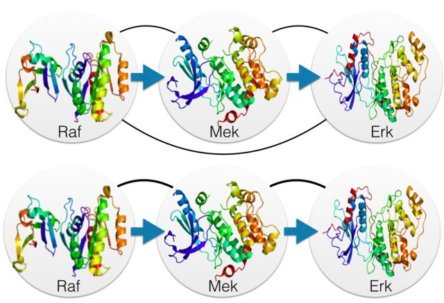

Fig1. In the MAPK signaling pathway, Raf regulates Mek, which regulates Erk. Top; the lines represent association - the activity of the kinases on this pathway are all correlated. Bottom: the lines represent conditional dependence, there is no conditional dependence edge from Raf to Erk because given you know Mek, knowing Raf tells you nothing about Erk. They are conditionally independent.

The problem of doing causal inference with large-scale experiments is two-fold. Firstly, sample size is typically far too small for the large number of features we measure. With the large-scale experiment described above, it is clear that viewing a scatter-plot between a pair of features that has only 3 points is uninformative – even if the points correlated perfectly, 3 points is not enough to conclude anything about the relationship with any confidence. But even with hundreds of samples, we are still plagued by spurious associations when the number of features is so large, since more features means greater chance associations will occur at random.

To illustrate, we ran a simulation where we first simulate a 20 features dataset each with a 100 Gaussian random measurements, then increase the number of features to 500. In both cases the features are completely independent. This means if we quantify association using Pearson correlation, any correlation we find will be completely spurious. We record the maximum correlation between the 20 feature set and the 500 feature set. We repeat this simulation 500 times.

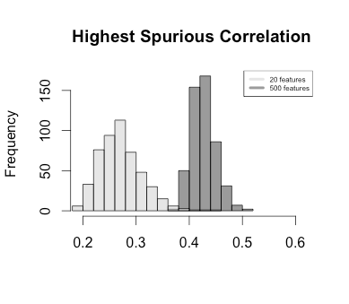

Fig2. As you increase the number of features, you get more high scoring spurious correlations.

The increased incidence of spurious correlation means increased false positives in detecting conditional dependence relationships. To illustrate, we repeat the previous simulation, except now expanding from 20 to only 100 features. In each of the 500 instances, we apply a search algorithm that iteratively performs conditional independence tests, returning a count of detected conditional dependence relationships. As before, since we simulated independent features, any conditional dependence relationship reported by this algorithm is a false positive, i.e. it doesn’t actually exist in the mechanism that generated the data.

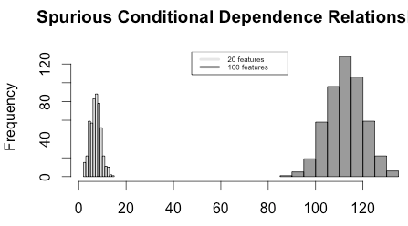

Fig3. Increasing the number of measured features means increasing the false positive detection of conditional dependence.

As you increase the number of features you measure, the number of false positive detection of conditional dependence explodes. What this means is that the computational methods for causal inference will fail for the typical large-scale experiment, because when their input data contains a large amount of features relative to sample size, they cannot reliably detect the conditional dependence relationships they need to infer causality.

The second problem is the requirement for interventions. As the number of features grows, the number of interventions needed to infer causality grows, and performing sufficient perturbation experiments becomes infeasible.

## III. Inferring causality from omics experiments

The problems outlined in section II paint a grim picture for causal learning in large datasets. Fortunately, these can be overcome, and effective causal learning can be a reality for large scale datasets. We proffer the approaches listed in the Causality Inference in Omics tools below.

1. *Refine the biological problem*, thus limiting the number of features. If the broader biological system is well-studied, it may be possible design an experiment that focuses on a specific part of the system of interest, then ask more specific questions of the data, such as whether a particular edge or pathway is present. The more specific the question, the less data is needed overall to make solid statistical inferences.
2. *Measure more samples*. If feasible, high throughput measurements that measure many samples (not just many features) provide the statistical power to tell true associations from spurious associations. This intuition motivates the use technologies that have lower throughput but enable measurement of more samples (or gather more data points per sample), for causal modeling. An example is single cell mass cytometry, where many thousands of cells per sample provide ample statistical power.
3. *Use prior knowledge*, not just from experts but also from noisier sources, to improve the process of searching for conditional independence. The MAPK pathway for instance, mentioned earlier, is well established and canonical. Assuming it, and other well established connections a priori can help reduce the number of possible associations, and enable more effective use of data. Knowledge about canonical causal relationships can be sourced from pathway databases such as KEGG. Another example is contextual information, such as spatial relations between phosphoproteins in the cell – causal inference algorithms can be formulated to weigh evidence of conditional dependence differently depending on whether phosphoproteins are from the same or different spatial compartments. Employing prior knowledge that provides evidence for the regulatory network reduces the number of connections and causal arcs under consideration, which allows the available data to make reliable statistical inferences.
4. *Employ targeted interventions selectively*. Targeted interventions perturb individual components of the system. An example is small molecule inhibitors which block the causal influence of a specific phoshoprotein on downstream components. Since it is usually prohibitive to perturb every target component of a system, it is strategic to prioritize application of targeted interventions to parts of the system that have the most potential for new discoveries. Selection of these perturbation targets can be based on prior knowledge - e.g. knowledge of which components are crucial players in the system of interest - or they can be applied iteratively, after an initial statistical analysis has revealed areas of the network in which causal inferences are not possible based on existing data. For instance, a resulting model graph with undirected edges can be inspected to reveal which nodes have potential to reveal the most causality if perturbed.
5. *Consider broad-scale interventions*. Traditionally, experiments consider a biological response to a particular stimulus, possibly in the context of an inhibitor. In contrast, broad-scale interventions sacrifice specificity to perturb many features in the system simultaneously. The advantage of this approach is that it can enable elucidation of causality across the entire system. Just as one intervention was sufficient to infer causality between 3 proteins Raf, Mek, and Erk, perturbing many things at once creates cascades of causal direction orientation across the broader network. This includes varying experimental conditions to activate multiple pathways. For example, signals from endocrine, paracrine, and autocrine ligands elicit various signaling responses in hepatocytes, thus interventions that cover this range of signals gives the best picture of the broader causal network of hepatocyte signaling. Similarly, interventions that go beyond receptor-level and perturb multiple components of the system bring cascading causal direct orientation deeper into the network. In contrast to targeted interventions, while it is difficult to know in advance what information will provided by broad-scale interventions, they provide more causal inference bang for your intervention buck.

The Causality in Omics tool list above provides impactful approaches that can drastically improve causal inference from omics datasets, by constraining the inference task, and thus allowing for accurate statistical inferences. For instance, the task of assessing which of all the possible KEGG pathways is present in a dataset will be far less error-prone than the task of assessing which of all possible combinations of my measured features might form a biological pathway.

How should the tools listed be used? They are most powerful when used in combination, and in fact the lines between them are somewhat arbitrary and frequently blurred. For instance, using tool #1 and tool #2 in concert can be thought of as reducing the breadth and increasing the depth of the investigation. Tools #4 and #5 call for use of interventions, but this task itself is complicated by measuring many things, since we have more features to expose to intervention. . Tool #3, prior biological knowledge, can be used to prioritize what to target with that limited set of interventions.